# 6.折線圖與箱型圖_Q slides

## 折線圖與箱型圖

### Da-Wei Chiang

## 大綱

- 折線圖
- 箱型圖
- 子圖的概念

## 折線圖

```
import matplotlib.pyplot

plot(x, y, lw, ls, label, color)

# x : x軸值
# y : y軸值
# lw : 線條寬度（line width）
# ls : 線條樣式（line style）
# label : 圖表標籤
# color : 線條顏色
```

## 折線圖

- 觀察兩變數之間的(趨勢)關係

## 練習資料集

- [imdb top 1000](https://drive.google.com/file/d/1J6lJiQ3PjMMh8PESBNM0klpM3z1UNLB0/view?usp=sharing)

```python
## 查看資料

import pandas
data = pandas.read_csv('imdb_top_1000.csv')
data
```

|  | Poster_Link | Series_Title | Released_Year | Certificate | Runtime | Genre | IMDB_Rating | Overview | Meta_score | Director | Star1 | Star2 | Star3 | Star4 | No_of_Votes | Gross |
| --- | --- | --- | --- | --- | --- | --- | --- | --- | --- | --- | --- | --- | --- | --- | --- | --- |
| 0 | https://m.media-amazon.com/images/M/MV5BMDFkYT... | The Shawshank Redemption | 1994 | A | 142 min | Drama | 9.3 | Two imprisoned men bond over a number of years... | 80.0 | Frank Darabont | Tim Robbins | Morgan Freeman | Bob Gunton | William Sadler | 2343110 | 28,341,469 |
| 1 | https://m.media-amazon.com/images/M/MV5BM2MyNj... | The Godfather | 1972 | A | 175 min | Crime, Drama | 9.2 | An organized crime dynasty's aging patriarch t... | 100.0 | Francis Ford Coppola | Marlon Brando | Al Pacino | James Caan | Diane Keaton | 1620367 | 134,966,411 |
| 2 | https://m.media-amazon.com/images/M/MV5BMTMxNT... | The Dark Knight | 2008 | UA | 152 min | Action, Crime, Drama | 9.0 | When the menace known as the Joker wreaks havo... | 84.0 | Christopher Nolan | Christian Bale | Heath Ledger | Aaron Eckhart | Michael Caine | 2303232 | 534,858,444 |
| 3 | https://m.media-amazon.com/images/M/MV5BMWMwMG... | The Godfather: Part II | 1974 | A | 202 min | Crime, Drama | 9.0 | The early life and career of Vito Corleone in ... | 90.0 | Francis Ford Coppola | Al Pacino | Robert De Niro | Robert Duvall | Diane Keaton | 1129952 | 57,300,000 |
| 4 | https://m.media-amazon.com/images/M/MV5BMWU4N2... | 12 Angry Men | 1957 | U | 96 min | Crime, Drama | 9.0 | A jury holdout attempts to prevent a miscarria... | 96.0 | Sidney Lumet | Henry Fonda | Lee J. Cobb | Martin Balsam | John Fiedler | 689845 | 4,360,000 |
| ... | ... | ... | ... | ... | ... | ... | ... | ... | ... | ... | ... | ... | ... | ... | ... | ... |
| 995 | https://m.media-amazon.com/images/M/MV5BNGEwMT... | Breakfast at Tiffany's | 1961 | A | 115 min | Comedy, Drama, Romance | 7.6 | A young New York socialite becomes interested ... | 76.0 | Blake Edwards | Audrey Hepburn | George Peppard | Patricia Neal | Buddy Ebsen | 166544 | NaN |
| 996 | https://m.media-amazon.com/images/M/MV5BODk3Yj... | Giant | 1956 | G | 201 min | Drama, Western | 7.6 | Sprawling epic covering the life of a Texas ca... | 84.0 | George Stevens | Elizabeth Taylor | Rock Hudson | James Dean | Carroll Baker | 34075 | NaN |
| 997 | https://m.media-amazon.com/images/M/MV5BM2U3Yz... | From Here to Eternity | 1953 | Passed | 118 min | Drama, Romance, War | 7.6 | In Hawaii in 1941, a private is cruelly punish... | 85.0 | Fred Zinnemann | Burt Lancaster | Montgomery Clift | Deborah Kerr | Donna Reed | 43374 | 30,500,000 |
| 998 | https://m.media-amazon.com/images/M/MV5BZTBmMj... | Lifeboat | 1944 | NaN | 97 min | Drama, War | 7.6 | Several survivors of a torpedoed merchant ship... | 78.0 | Alfred Hitchcock | Tallulah Bankhead | John Hodiak | Walter Slezak | William Bendix | 26471 | NaN |
| 999 | https://m.media-amazon.com/images/M/MV5BMTY5OD... | The 39 Steps | 1935 | NaN | 86 min | Crime, Mystery, Thriller | 7.6 | A man in London tries to help a counter-espion... | 93.0 | Alfred Hitchcock | Robert Donat | Madeleine Carroll | Lucie Mannheim | Godfrey Tearle | 51853 | NaN |

1000 rows × 16 columns

## 練習

- 請依據`Released_Year`及`Certificate`繪製平均分數折線圖
  - `Released_Year`取大於`2014`年的資料
  - `Certificate`取大於`U、A、UA`三類的資料
  - 取`Released_Year`及`Certificate`兩者的平均分數（平均分數取到小數點第一位）
  - 請設定`x`、`y`軸名稱、圖片`title`並呈現圖例
  - 資料點`A`以圓形呈現、`U`以三角形呈現、`UA`以方形呈現
  - 資料線`A`以實線呈現、`U`以虛線呈現、`UA`以點線呈現

## 堆疊折線圖

```
plt.stackplot(x, y1, y2, colors, labels)
```

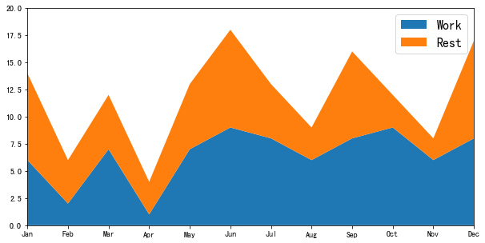

```python
## 範例 - 堆疊折線圖基礎
import matplotlib.pyplot as plt
import calendar

plt.figure(figsize=(10, 5))
month = range(1, 13)
working_time = [6, 2, 7, 1, 7, 9, 8, 6, 8, 9, 6, 8]
rest_time = [8, 4, 5, 3, 6, 9, 5, 3, 8, 3, 2, 9]
plt.stackplot(month, working_time, rest_time, labels=["Work", "Rest"])
plt.axis([1, 12, 0, 20])
plt.xticks(range(1, 13), calendar.month_abbr[1:])
plt.legend(fontsize=16)
plt.show()
```

## 練習

- 已知一位工程師一週的生活作息時間花費如下
  - 週一～週日休息時間:`[6, 5, 5, 8, 4, 6, 12]`
  - 週一～週日工作時間:`[10, 12, 14, 12, 14, 12, 2]`
  - 週一～週日吃飯時間:`[3, 4, 2, 3, 3, 3, 4]`
  - 週一～週日玩樂時間:`[5, 3, 3, 1, 3, 3, 6]`
- 請繪製圖表觀看結果

## 箱型圖

- 呈現資料分布狀況
- 呈現資料偏態
- 明確識別是否有異常值

[figure not shown]

## 箱型圖

```
import matplotlib.pyplot as plt  #引用

plt.boxplot(data, labels, sym, patch_artist)   #繪圖

#data: 繪圖資料
#labels:箱子標籤
#sym: 異常直標籤, 預設為b
#patch_artist: 布林值, 箱體顏色
```

[figure not shown]

```python
## 範例 - 箱型圖基礎

import random
import matplotlib.pyplot as plt
data = []
data1 = [random.randint(1, 100) for i in range(50)]
data1.append(200)
data2 = [random.randint(100, 200) for i in range(51)]
data.append(data1)
data.append(data2)
plt.boxplot(data)
plt.xticks(range(1, 3), ["one", "two"])
plt.grid()
plt.show()
```

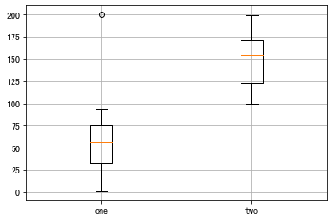

```python
## 範例 - labels

import random
import matplotlib.pyplot as plt

data = []
data1 = [random.randint(1, 100) for i in range(50)]
data1.append(200)
data2 = [random.randint(100, 200) for i in range(51)]
data.append(data1)
data.append(data2)
plt.boxplot(data, labels=["one", "two"])
#plt.xticks(range(1, 3), ["one", "two"])
plt.grid()
plt.show()
```

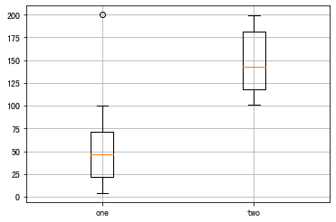

```python
## 範例 - labels

import random
import matplotlib.pyplot as plt

data = []
data1 = [random.randint(1, 100) for i in range(50)]
data1.append(200)
data2 = [random.randint(100, 200) for i in range(51)]
data.append(data1)
data.append(data2)
plt.boxplot(data, labels=["one", "two"])
#plt.xticks(range(1, 3), ["one", "two"])
plt.grid()
plt.show()
```

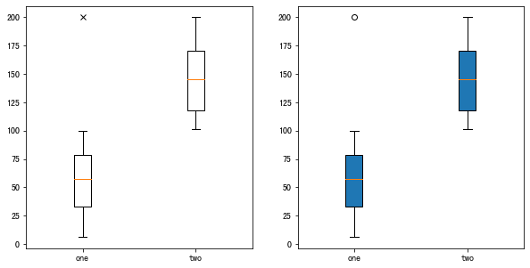

```python
## 範例 sym, patch_artist
import random
import matplotlib.pyplot as plt

data = []
data1 = [random.randint(1, 100) for i in range(50)]
data1.append(200)
data2 = [random.randint(100, 200) for i in range(51)]
data.append(data1)
data.append(data2)
plt.figure(figsize=(10, 5))
plt.subplot(121)
plt.boxplot(data, labels=["one", "two"], sym='x')
plt.subplot(122)
plt.boxplot(data, labels=["one", "two"], patch_artist=True)
plt.show()
```

## 練習

- 請自行練習基本箱型圖設定

## 異常值標記設定

```
flierprops({markeredgecolor:???, markerfacecolor:???, marker:???, markersize:???})

# markeredgecolor: 標記邊線顏色
# markerfacecolor: 標記顏色
# marker: 標記樣式
# markersize: 標記大小
```

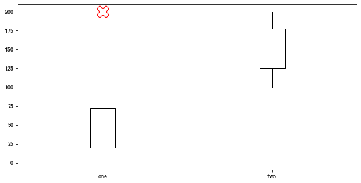

```python
## 範例 - flierprop

import random
import matplotlib.pyplot as plt

data = []
data1 = [random.randint(1, 100) for i in range(50)]
data1.append(200)
data2 = [random.randint(100, 200) for i in range(51)]
data.append(data1)
data.append(data2)
mark_setting = {'markeredgecolor': 'red', 'markerfacecolor': 'white', 'marker': 'X', 'markersize': 20}
plt.figure(figsize=(10, 5))
plt.boxplot(data, labels=["one", "two"], flierprops=mark_setting)
plt.show()
```

## 水平箱型圖 - vert設定

```
plt.boxplot(..., vert=False)
```

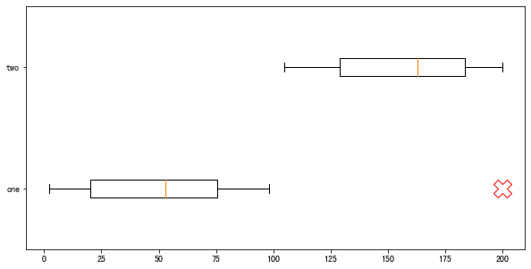

```python
## 範例 - 水平箱型圖

import random
import matplotlib.pyplot as plt

data = []
data1 = [random.randint(1, 100) for i in range(50)]
data1.append(200)
data2 = [random.randint(100, 200) for i in range(51)]
data.append(data1)
data.append(data2)
mark_setting = {'markeredgecolor': 'red', 'markerfacecolor': 'white', 'marker': 'X', 'markersize': 20}
plt.figure(figsize=(10, 5))
plt.boxplot(data, labels=["one", "two"], flierprops=mark_setting, vert=False)
plt.show()
```

## 練習

- 請自行練習異常點設置及水平箱型圖

## 練習資料集

- [Pokemon Detail Data](https://drive.google.com/file/d/1yQQs0ueFive87-UQAK4Mk6RIHFBJvWsQ/view?usp=sharing)

```python
## 查看資料

import pandas as pd

data = pd.read_csv('pokemon.csv')
data
```

|  | Name | Total | HP | Attack | Defence | Sp_attack | Sp_defence | Speed |
| --- | --- | --- | --- | --- | --- | --- | --- | --- |
| 0 | Bulbasaur | 318 | 45 | 49 | 49 | 65 | 65 | 45 |
| 1 | Ivysaur | 405 | 60 | 62 | 63 | 80 | 80 | 60 |
| 2 | Venusaur | 525 | 80 | 82 | 83 | 100 | 100 | 80 |
| 3 | Mega Venusaur | 625 | 80 | 100 | 123 | 122 | 120 | 80 |
| 4 | Charmander | 309 | 39 | 52 | 43 | 60 | 50 | 65 |
| ... | ... | ... | ... | ... | ... | ... | ... | ... |
| 1040 | Glastrier | 580 | 100 | 145 | 130 | 65 | 110 | 30 |
| 1041 | Spectrier | 580 | 100 | 65 | 60 | 145 | 80 | 130 |
| 1042 | Calyrex | 500 | 100 | 80 | 80 | 80 | 80 | 80 |
| 1043 | Mega Calyrex | 680 | 100 | 165 | 150 | 85 | 130 | 50 |
| 1044 | Mega Calyrex X | 680 | 100 | 85 | 80 | 165 | 100 | 150 |

1045 rows × 8 columns